# Ableitung, Extrema, Taylor

[figure not shown]

Quelle: Wikipedia - Differencial quotiont of a function

*Jochen Illerhaus*

# Prüfungsanmeldung

- Prüfung am: 09.03.2018, 11:00 - 13:00 Uhr
- Anmeldung ab sofort (bis 10.02.2018, Vorlesungsende)
- Anmeldeschluss unbedingt beachten keine Kulanzregelung in diesem Jahr.
- Online über Studierendenportal https://campus.studium.kit.edu/exams/registration.php
- Abmeldung online bis zum Tag vor der Prüfung
- Abmeldung mit Studentenausweis unmittelbar vor der Prüfung
- Keine Abmeldung nach Beginn der Prüfung
- Einige Tage nach der Anmeldung nochmal einloggen, kontrolliert und abspeichern.
- Die genaue Hörsaalverteilung wird ab Montag, den 19.02.2018 durch Audhang am Brett neben dem Zimmer 2.027 (Geb. 20.30) bekanntgegeben.
- Weitere Informationen: http://www.math.kit.edu/iana2/lehre/hm1etec2017w/de

Februar

März

| Mo | Di | Mi | Do | Fr | Sa | So |
| --- | --- | --- | --- | --- | --- | --- |
|  |  |  | 1 | 2 | 3 | 4 |
| 5 | 6 | 7 | 8 | 9 | 10 | 11 |
| 12 | 13 | 14 | 15 | 16 | 17 | 18 |
| 19 | 20 | 21 | 22 | 23 | 24 | 25 |
| 26 | 27 | 28 |  |  |  |  |

| Mo | Di | Mi | Do | Fr | Sa | So |
| --- | --- | --- | --- | --- | --- | --- |
|  |  |  | 1 | 2 | 3 | 4 |
| 5 | 6 | 7 | 8 | 9 | 10 | 11 |
| 12 | 13 | 14 | 15 | 16 | 17 | 18 |
| 19 | 20 | 21 | 22 | 23 | 24 | 25 |
| 26 | 27 | 28 | 29 | 30 | 31 |  |

# Ableitung (Derivative)

$$ \frac{df}{dx} = f'(x) := \lim_{h \to \infty} \frac{f(x+h) \, - \, f(x)}{h} $$

[figure not shown]

Quelle: Wikipedia - Derivative

## Ableitungsregeln (Differentiation rules):

- Polynome: $\big( x^a \big)' = a x^{a-1} \; \; \forall \; a \neq 0$
- Logaritmen: $\big( \ln(x) \big)' = \frac{1}{x}$
- Linearität: $\big( au(x) \; + \; bv(x) \big)' = a u'(x) \; + \; b v'(x)$
- Ketten-regel: $\Big( u\big(v(x) \big) \Big)' = u'\big(v(x)\big) \; v'(x)$
- Produkt-regel $\big( u(x) \; v(x) \big)' = u'(x) \; v(x) \; + \; u(x) \; v'(x)$

## Blatt 10 Aufgabe 1

Berechnen Sie die Ableitungen folgender Funktionen.

- **(b)** $$ f: \; \; (0, \infty) \to \mathbb{R}, \; x \mapsto x^{\sqrt[3]{x}} $$

$f(x) = x^{\sqrt[3]{x}}$

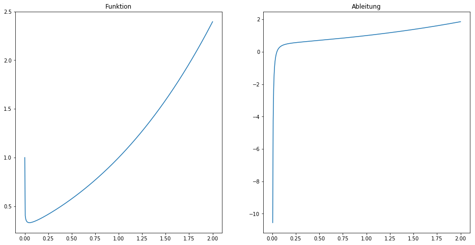

```python
def plotFuncDiff(func, diff, start, end):
    x = np.linspace(start, end, 400)
    fig, (axa, axb) = plt.subplots(1, 2, figsize=(16, 8))
    axa.plot(x, func(x))
    axa.set_title("Funktion")
    axb.plot(x, diff(x))
    axb.set_title("Ableitung")

with np.warnings.catch_warnings():
    np.warnings.filterwarnings('ignore')
    plotFuncDiff(lambda x: x**(x**(1/3)), lambda x: ((np.log(x)+3)/(3*x**(2/3))) * x**(x**(1/3)), 0, 2)

disp.HTML("<h1>$f(x) = x^{\\sqrt[3]{x}}$</h1>")
```

# Mittelwertsatz (Mean value theorem)

[figure not shown]

$$ f \text{dbar auf $(a, b)$ und stetig auf $[a, b]$} \, \Rightarrow \, \exists \, \xi \in (a, b): \; \; f'(\xi) = \frac{f(b) - f(a)}{b-a} $$

Quelle: Wikipedia - Mean value theorem

## Mittelwertsatze (Mean value theorem)

$$ f \text{dbar auf $(a, b)$ und stetig auf $[a, b]$} \, \Rightarrow \, \exists \, \xi \in (a, b): \; \; f'(\xi) = \frac{f(b) - f(a)}{b-a} $$

## Blatt 10 Aufgabe 2

- **(b)** Zeigen Sie mit Hilfe des Mittelwertsatzes die folgende Abschätzung: $$ x \ln(x) \, - \, y \ln(y) \leq (x-y) \big(1 \, + \, \ln(x) \big) \; \; \; \forall x > y > 0 $$

## Blatt 10 Aufgabe 3

Beweisen Sie, dass die Funktion $f$ konstant ist, und bestimmen Sie die Konstante.

$$ f: \; (0, \infty) \to \mathbb{R}, \; x \mapsto \arctan(x) \, + \, \arctan(x^-1) $$

### Hinweise

- $\tan(x) = \frac{\sin(x)}{\cos(x)}$
- $\big(\sin(x)\big)' = \cos(x)$
- $\big(\cos(x)\big)' = -\sin(x)$

# Blatt 10 Aufgabe 4

Bestimmen Sie die Grenzwerte

**b)** $$ \lim_{x \to \frac{\pi}{4}} \frac{4 \sin^2(x) \cos^2(x) - 1}{\big( \tan(x) \big)^{1/2} - 1} $$

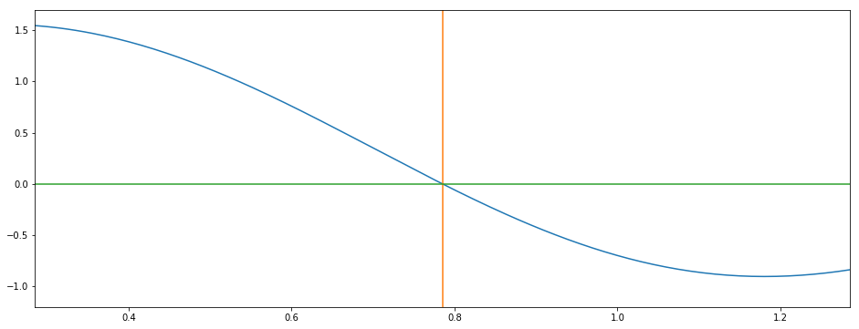

```python
a = 0.5
x = np.linspace(np.pi/4 - a, np.pi/4 + a, 200)
y = (4*(np.sin(x)*np.cos(x))**2 - 1)/(np.sqrt(np.tan(x)) - 1)
fig, ax = plt.subplots(1, 1, figsize=(16, 6))
ax.plot(x, y)
line = lambda ax, a, b: ax.plot([a[1], b[1]], [a[0], b[0]])
line(ax, [-3, np.pi/4], [3, np.pi/4])
line(ax, [0, -5], [0, 5])
ax.set_ylim([-1.2, 1.7])
ax.set_xlim([np.pi/4 - a, np.pi/4 + a]);
```

# Blatt 10 Aufgabe 6

**(Fermatsches Brechungsgesetz)** Ein Lichtstrahl von Punkt P zum Punkt Q schlägt den zeitkürzesten Weg ein. Dabei seien die Lichtgeschwindigkeiten oberhalb bzw. unterhalb der x-Achse durch $c_1$ und $c_2$ gegeben. Leiten Sie das Brechungsgesetz her, d.h. die Beziehung zwischen $\alpha$, $\beta$, $c_1$, $c_2$.

[figure not shown]

# Blatt 10 Aufgabe 7

Berechnen Sie Maximum und Minimum der Funktionen:

**(b)** $$ g: [0, 10] \to \mathbb{R}, \; x \mapsto -6x \, + \, \Big( \big| x - 3 \big| + 2 \Big)^2 $$

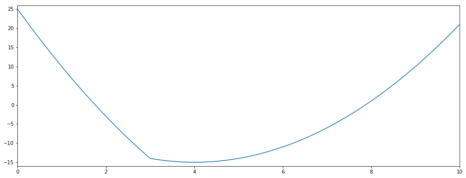

```python
horizontal = lambda ax, a, b, y: ax.plot([a, b], [y, y])
vertical = lambda ax, x, a, b: ax.plot([x, x], [a, b])
def point(ax, a, b):
    vertical(ax, a, -100, 100)
    horizontal(ax, -100, 100, b)

x = np.linspace(0, 10, 400)
y = -6*x + (np.abs(x-3)+2)**2
fig, ax = plt.subplots(1, 1, figsize=(16, 6))
ax.plot(x, y)

#point(ax, 0, 25)
#point(ax, 4, -15)

ax.set_ylim([-16, 26])
ax.set_xlim([0, 10]);
```

# Satz von Taylor

[GeoGibra demo (Externer Link)](https://www.geogebra.org/classic/frkWCH4U) $$ f(x) = T_n\big(f, x_0\big)(x) \; + \; R_n\big(f, x_0 \big)(x) $$ $$ T_n\big(f, x_0\big)(x) = \sum_{n=0}^n \frac{f^{(n)}(x)}{n!} (x - x_0)^n $$ $$ R_n\big(f, x_0\big)(x) = \frac{f^{(n+1)}(\xi)}{(n+1)!} (x - x_0)^{n+1} \; \text{mit} \; \xi \in \big(\min\{x, x_0\}, \max\{x, x_0\}\big) $$

# Blatt 10 Aufgabe 8

**(b)** Approximieren Sie die Funktion $f(x) := e^{−x}+11+x$ durch das Taylorpolynom $T_2 \big(f;\frac{1}{2} \big)$ und geben Sie eine Konstante $C >0$ an so, dass für alle $x \in [0,1]$ gilt: $$ \Big| f(x) - T_2\Big(f; \frac{1}{2}\Big)(x) \Big| \leq 6C\big| x - \frac{1}{2} \big|^3 $$